# RMarkdown and Version Control with git

Lukas Schmid, Chân Lê

17 1 2020

# **Introduction to R Markdown**

## **1. General**

RMarkdown can be used to save and execute codes, as well as generate high-quality reports to be shared with the audience.

## **2. Installation**

### **a. Prerequisite**

Make sure that you have the **latest version of R and RStudio**. It was not officially mentioned on the RMarkdown official guide, but I did run into troubles trying to install RMarkdown without knowing that some conflicts could exist if you were not to get R in your computer updated.

### **b. Install RMarkdown**

Next you can install RMarkdown package in R:

```r
# Install from CRAN
install.packages('rmarkdown')

# Or if you want to test the development version,
# install from GitHub
if (!requireNamespace("devtools"))
  install.packages('devtools')
devtools::install_github('rstudio/rmarkdown')
```

### **c. LaTeX for PDF output**

If you want to generate PDF output, you will need to install LaTeX. For R Markdown users who have not installed LaTeX before, you can install TinyTeX (https://yihui.name/tinytex/):

```r
install.packages("tinytex")
tinytex::install_tinytex()  # install TinyTeX
```

## **3. Basics**

### **a. Text formating**

Write normally for plain text

> Highlight some chunk of text or blockquotes with the greater-than sign

Write in italics using *single asterisks* or *single underscores*

Wrie in bold using **double asterisks** or **double underscore**

You can have different sizes of header with the number sign #:

# Header 1

## Header 2

### Header 3

#### Header 4

##### Header 5

###### Header 6

Alternatively, you can add a horinzontal line to separate sections of your report:

Inline code blocks are highlighted using back-ticks, for example the package `ggplot2`

- You can create bullet points by setting an asterisk, just remember **the space between the asterisk and your text**:
  - Then add first sub-point with a plus sign
  - Another sub-point
    - Then a sub-sub-point using minus sign
1. You can create numbered list with, well, numbers.
2. Something something
   1. A sub-point (with three spaces at the beginning, to get the indentation)
   2. Yet another sub-point

And finally, you can also run code inline. So, if I want to report the mean of some variable directly in the text, I can write `#r mean(cars$speed)` (without the hashtag) to get the result, 15.4.

### **b. Chunk code & Chunk options**

If you want to execute your code in RMarkdown, put them into the following code chunk brackets ( **or press Ctrl + ALt + I** ). The codes are displayed in a gray box, while the outputs are in a white box. For example:

```r
  library(tidyr)
  library(ggplot2)
  paste("Welcome","to","RMarkDown!")
```

```
## [1] "Welcome to RMarkDown!"
```

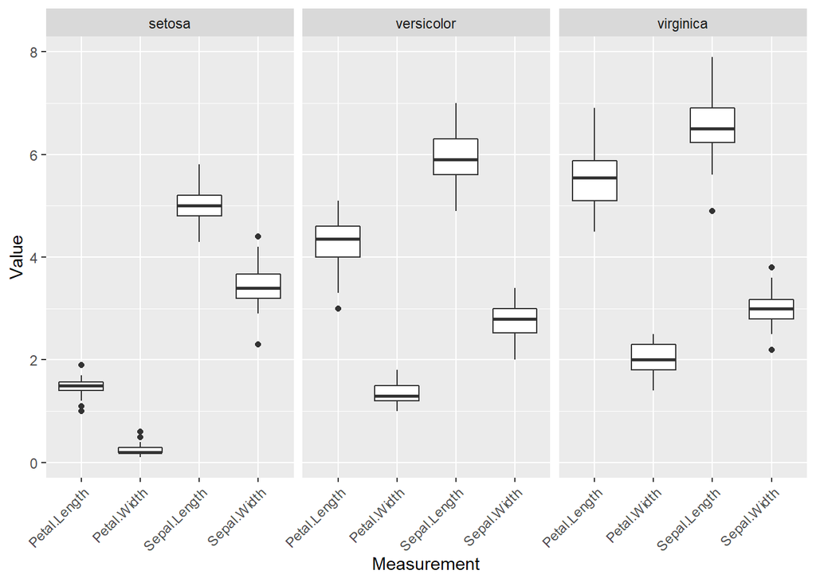

```r
  data <- iris
  data.plot <- data %>% pivot_longer(-Species, names_to = "Measurement", values_to = "Value")
  ggplot(data.plot, aes(group = Measurement, x = Measurement, y = Value)) +
    geom_boxplot() +
    facet_grid(. ~ Species) +
    theme(axis.text.x = element_text(angle = 45, hjust = 1))
```

```r
  lm.model <- lm(Petal.Length ~ Sepal.Length + Sepal.Width + Petal.Width, data = data)
  summary(lm.model)
```

```
##
## Call:
## lm(formula = Petal.Length ~ Sepal.Length + Sepal.Width + Petal.Width,
##     data = data)
##
## Residuals:
##      Min       1Q   Median       3Q      Max
## -0.99333 -0.17656 -0.01004  0.18558  1.06909
##
## Coefficients:
##              Estimate Std. Error t value Pr(>|t|)
## (Intercept)  -0.26271    0.29741  -0.883    0.379
## Sepal.Length  0.72914    0.05832  12.502   <2e-16 ***
## Sepal.Width  -0.64601    0.06850  -9.431   <2e-16 ***
## Petal.Width   1.44679    0.06761  21.399   <2e-16 ***
## ---
## Signif. codes:  0 '***' 0.001 '**' 0.01 '*' 0.05 '.' 0.1 ' ' 1
##
## Residual standard error: 0.319 on 146 degrees of freedom
## Multiple R-squared:  0.968,  Adjusted R-squared:  0.9674
## F-statistic:  1473 on 3 and 146 DF,  p-value: < 2.2e-16
```

Try not to crowd your code chunk like that. Instead of that, divide your work into smaller steps so you can comment on them easily.

On this second attempt, we you should you some essential code chunk options to make your report more clear and concise.

- First, I want to call some needed packages. If you want to **run these codes but not include them in the report**, type in chunk option `include = FALSE`

> The code ran but nothing appeared
- If you only want to show some **codes without running them**, type in chunk option `eval = FALSE`

```r
  paste("Welcome","to","RMarkDown!")
```

- On the other hand, if you want to show some results without the codes, type in chunk option `echo = FALSE`

```
## [1] "Welcome to RMarkDown!"
```

**Summary:** Chunks have chunk options that change their behaviour when knitted. By default, code in all chunks will be run by R, the code will be displayed in the final Markdown-document and the outputs (if any) will be displayed. There are some useful options to change this behaviour (standard behaviour is mentioned):

- `eval = TRUE`: Run code in chunk
- `echo = TRUE`: display the source code in the document
- `results = markup`: how to display the results of a code chunk
- `include = TRUE`: Include anything from the code at all (`include = FALSE` is equal to `echo = FALSE, results = 'hide', warning = FALSE, message = FALSE`)

Additionally, the first option in a code chunk can be the label of that chunk. Labels are useful when you have lots of them and try to debug your document; they will also be used for filenames in plots.

```r
  paste("Welcome","to","RMarkDown!")
```

```
## [1] "Welcome to RMarkDown!"
```

- Now I can load the data and view it.

```r
  data <- iris
  head(data)
```

```
##   Sepal.Length Sepal.Width Petal.Length Petal.Width Species
## 1          5.1         3.5          1.4         0.2  setosa
## 2          4.9         3.0          1.4         0.2  setosa
## 3          4.7         3.2          1.3         0.2  setosa
## 4          4.6         3.1          1.5         0.2  setosa
## 5          5.0         3.6          1.4         0.2  setosa
## 6          5.4         3.9          1.7         0.4  setosa
```

- The next step is to transform it into long-format for the plotting:

```r
  data.plot <- data %>% pivot_longer(-Species, names_to = "Measurement", values_to = "Value")
  head(data.plot)
```

```
## # A tibble: 6 x 3
##   Species Measurement  Value
##   <fct>   <chr>        <dbl>
## 1 setosa  Sepal.Length   5.1
## 2 setosa  Sepal.Width    3.5
## 3 setosa  Petal.Length   1.4
## 4 setosa  Petal.Width    0.2
## 5 setosa  Sepal.Length   4.9
## 6 setosa  Sepal.Width    3
```

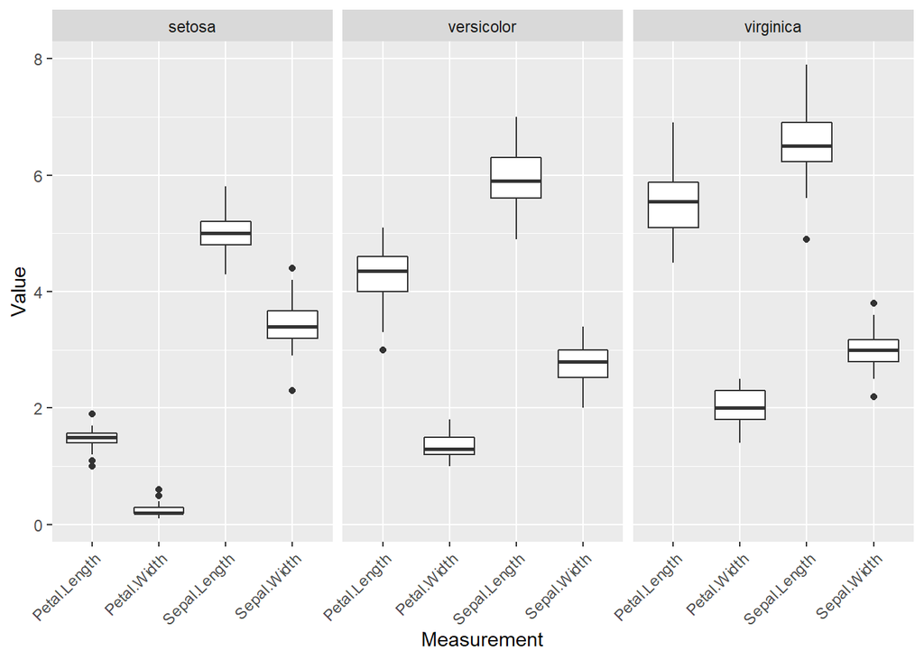

Figure 1: possible caption for the graph

```r
  ggplot(data.plot, aes(group = Measurement, x = Measurement, y = Value)) +
    geom_boxplot() +
    facet_grid(. ~ Species) +
    theme(axis.text.x = element_text(angle = 45, hjust = 1))
```

### **c. Tables in RMarkdown using `knitr` and `kableExtra`**

As a default, you can always show a data set by just calling it directly. The dataset is shorten for the purpose of demonstration.

```r
  data <- head(data, 10)
  data
```

```
##    Sepal.Length Sepal.Width Petal.Length Petal.Width Species
## 1           5.1         3.5          1.4         0.2  setosa
## 2           4.9         3.0          1.4         0.2  setosa
## 3           4.7         3.2          1.3         0.2  setosa
## 4           4.6         3.1          1.5         0.2  setosa
## 5           5.0         3.6          1.4         0.2  setosa
## 6           5.4         3.9          1.7         0.4  setosa
## 7           4.6         3.4          1.4         0.3  setosa
## 8           5.0         3.4          1.5         0.2  setosa
## 9           4.4         2.9          1.4         0.2  setosa
## 10          4.9         3.1          1.5         0.1  setosa
```

There is another alternative to displaying a data set, or broadly speaking, a table. With `knitr` and `kableExtra`

```r
  #install.packages("knitr")
  #install.packages("kableExtra")
  library(knitr)
  library(kableExtra)
  head(data) %>%
    kable() %>%
    kable_styling()
```

| Sepal.Length | Sepal.Width | Petal.Length | Petal.Width | Species |
| --- | --- | --- | --- | --- |
| 5.1 | 3.5 | 1.4 | 0.2 | setosa |
| 4.9 | 3.0 | 1.4 | 0.2 | setosa |
| 4.7 | 3.2 | 1.3 | 0.2 | setosa |
| 4.6 | 3.1 | 1.5 | 0.2 | setosa |
| 5.0 | 3.6 | 1.4 | 0.2 | setosa |
| 5.4 | 3.9 | 1.7 | 0.4 | setosa |

Other advanced formatting of tables (e.g. their alignement, stretching over multiple pages…) in PDFs can be more cumbersome. Here, we only reference to https://bookdown.org/yihui/rmarkdown/r-code.html#tables. Vignettes on how to use kableExtra can be found on the [CRAN-page](https://cran.r-project.org/web/packages/kableExtra/index.html).

## **4. YAML**

## **5. Remarks & Literature**

- A (newer version)cheatsheet of can be found here: https://github.com/rstudio/cheatsheets/raw/master/rmarkdown-2.0.pdf

# **Version control with git**

## **1. General principle**

Git is a version control software for line-based data (that means, you can version control things like .txt, .csv, LaTeX, R, and other code, but not formats like .PDF, .docx, .xlsx, ar images). It is useful because it is (comparatively) simple and not storage-intensive.

You can use it locally, but you can also connect it to specialised websites (like [GitHub](https://github.com/) or [BitBucket](https://bitbucket.org/)) - this ultimately means that you have an opportunity to back-up all of your code, for no money, on the internet (and I think it is relatively secure, so your code will not be stolen). GitHub also has a good [education plan](https://education.github.com/pack) which gives you access to some cool programs.

## **2. How it works**

Many examples on the web use git from your command line. This is probably a skill worth to learn at some point; however, you can do without - and as one website out it, “no one is handing out nerd badges”, so using the command line because it looks cool is probably stupid (though we all do it, of course). So here come only the basic basics.

### **a. Creating a repsository**

Git relies on so-called repositories. For us, they are simply folders that contain an additional `.git` folder and sometimes a `.gitignore` file, and of course everything you cant to version-control.

You can create a repository locally on your computer. If you want to use that repository online, you can later push it to an online service. If you want to use it online from the start, better create the repository online and then ‘clone’ it to your machine.

### **b. Applying changes**

Whenever something changes in your repository, you have to first **add** the changes to your index. Because the index is the staging area (german: Zwischenschritt), this is also called **staging**. After changes are added, they are not yet safed! To actually apply changes, you have to **commit** them. When committing, you have to specify a commit message that usually contains info about what you have done in that commit.

If you use an online repo, you have to **push** those changes (to the server) so they not only exist on your local machine.

### **c. Workflow**

Of course, if you work online, you also have to check for changes on the server (though this is less of an issue if you work alone on only one machine). This is called to **pull**. As a result, we can summarise the following ideal workflow:

1. Pull to sync your local repo with the online repo.
2. Work.
3. Stage changes (whenever it seems reasonable; these can be very small steps! The more and smaller steps you stage and commit, the higher is the change that you can return to a well working version of your code.)
4. Commit the changes.
5. Push the changes.
6. Repeat 2 to 6 until you’re done.

### **d. Branches and merges**

When you pull and there are changes in the online repo, these changes will automatically be applied to your code. In some cases (e.g. the same line has been changed in the online and the local repo, but in different ways), you have to manually resolve these merge conflicts. This usually means to decide which line should be used.

When more than one person works on a code, it is advisable to branch. This means that effects in one branch won’t affect any other branch. However, due to time and ressource constraints, we won’t cover this topic here.

## **3. Appendix: glossary**

- working directory: contains all your files
- repo: short for repository
- to clone a repo: copy an existing online-repo to your local machine
- HEAD: the last version of your repo (or the branch you are currently in); not the same as the working directory
- index: the staging area where you ‘park’ changes until you commit them
- to stage or add change: to apply changes to the index
- to commit changes: to add changes from the index to the HEAD, thus making them visible
- to push changes: to add changes from your local repo to the online repo
- to pull changes: to add changes from your online repo to the local repo